# POL40950: Introduction to Statistics

Homework 2

Nilesh Harekal Nayak

Deadline: 3 November 2021

## Instructions

- Rename this file to your LASTNAME_FIRSTNAME_homework02.Rmd and insert your name at the header of this script (see `INSERT YOUR NAME`).
- If an answer to a question requires code, add the code in the code block below. For questions that need interpretations or explanations, write your answer in *italics* below the question.
- **This script will only knit if `data_castanhosilva_proksch_apsr.rds` is stored in the same folder as this RMarkdown file! The dataset is available in the “Homeworks” folder on Brightspace.**
- Please knit this file as an .html document and upload the .html document to the assignment folder on Brightspace.
- If the code for one of the questions is not working, leave the code in the chunk, but change the beginning of the chunk to `{r,eval=FALSE}`. Only do this as a last resort, though.

In this homework, we will explore the data used in Castanho Silva and Proksch (2021) and reproduce their main analysis. The paper was published in the American Political Science Review, one of the flagship journals of the discipline (https://doi.org/10.1017/S000305542000081). To answer the questions, you must (a) read their research paper carefully and (b) inspect the codebook (PDF file in the Homeworks folder) before you start answering the questions. You need the following packages to solve all questions: **tidyverse**, **texreg**, and **ggeffects**.

Make sure to install the three packages.

```r
# run the following lines only once in your CONSOLE
#install.packages("ggeffects")
#install.packages("tidyverse")
#install.packages("texreg")

library(tidyverse)
library(texreg)
library(ggeffects)
```

In this homework, you can get up to 100 points (+ 5 bonus points). The grade conversion scheme from the syllabus will be applied.

```r
# make sure to store the dataset in the same folder as this .Rmd file!
dat_raw <- readRDS("data_castanhosilva_proksch_apsr.rds")
#head(dat_raw)
```

## Exploring the Dataset

1. What are the two main research questions in Castanho Silva and Proksch (2021)? [5 points]

*1) how social media bots’ influence on European politics?*

*2) which politicians and parties benefit most from them?*

2. What does the variable `sent.overall` measure? Check the paper and codebook to find out. What is the minimum, maximum, mean, and range of this variable? What does `sent.eu` measure? What is the minimum, maximum, mean, and range of this variable? [5 points]

```r
dat_raw %>% summarise(min = min(sent.overall, na.rm = TRUE), max = max(sent.overall, na.rm = TRUE),
mean = mean(sent.overall, na.rm = TRUE), range = (max(sent.overall, na.rm = TRUE) - min (sent.overall, na.rm = TRUE)))
```

```
##         min      max      mean    range
## 1 -1.686399 2.833213 0.4260061 4.519612
```

```r
dat_raw %>% summarise(min = min(sent.eu, na.rm = TRUE), max = max(sent.eu, na.rm = TRUE),
mean = mean(sent.eu, na.rm = TRUE), range = (max(sent.eu, na.rm = TRUE) - min (sent.eu, na.rm = TRUE)))
```

```
##         min      max      mean   range
## 1 -3.044522 3.433987 0.4350735 6.47851
```

*sent.overall refers to estimated sentiment of all tweets posted by the MP from February to the end of June 2018, using the Lexicoder Sentiment Dictionary*

*sent.eu refers to estimated sentiment of the EU-related tweets posted by the MP from February to the end of June 2018, using the Lexicoder Sentiment Dictionary*

3. Get the number of observations (=number of politicians) per country (note: you can use `group_by()` and `count()`). [5 points]

```r
dat_raw_pol_per_country = dat_raw %>% group_by(country) %>% count()
dat_raw_pol_per_country
```

```
## # A tibble: 25 x 2
## # Groups:   country [25]
##    country     n
##    <chr>   <int>
##  1 Austria    37
##  2 Belgium    19
##  3 Croatia     3
##  4 Cyprus     13
##  5 Czechia    28
##  6 Denmark    64
##  7 Estonia    16
##  8 Finland   114
##  9 France    398
## 10 Germany   240
## # ... with 15 more rows
```

4. Using the data frame created in the question above, create a plot with the number of politicians per country on the x-axis and the country names (use the `country_clean` variable) on the y-axis. Order the countries based on the number of politicians in the dataset (you can use `reorder()`, like in the first homework). [5 points]

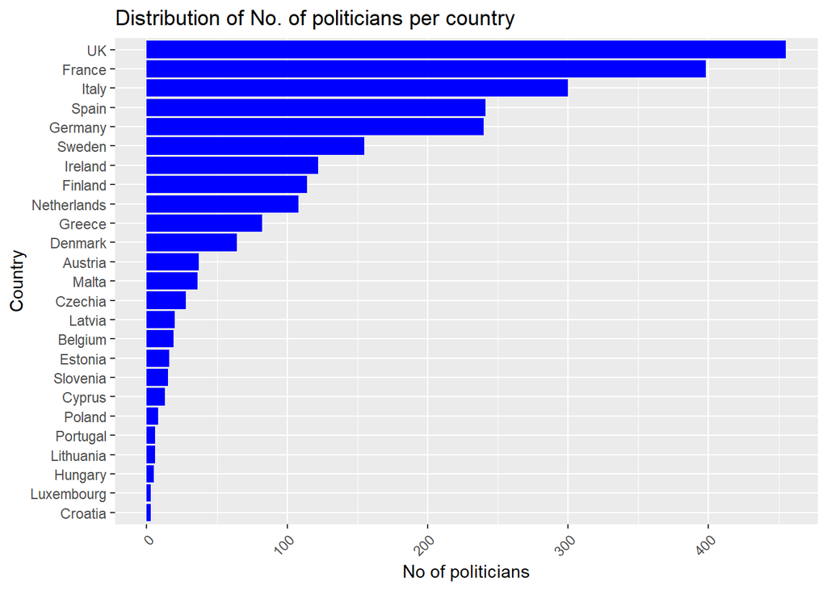

```r
dat_raw_pol_per_country %>% ggplot(aes(x = dat_raw_pol_per_country$n, reorder(dat_raw_pol_per_country$country, dat_raw_pol_per_country$n))) + geom_col(fill = "blue") + theme(axis.text.x = element_text(angle = 45, hjust=1)) +  labs(x = "No of politicians", y = "Country", title = "Distribution of No. of politicians per country")
```

## Assessing Variation and Differences in Sentiment

5. Group the original dataset by country and get the average of `sent.eu` for each country using `summarise()`. Store this data frame as a new object. [5 points]

```r
summarised_avg_sent_eu = dat_raw %>% group_by(country = dat_raw$country) %>% summarise(average_sent_eu = mean(sent.eu, na.rm = TRUE))
summarised_avg_sent_eu
```

```
## # A tibble: 25 x 2
##    country average_sent_eu
##    <chr>             <dbl>
##  1 Austria           0.543
##  2 Belgium           0.458
##  3 Croatia           0.452
##  4 Cyprus            0.428
##  5 Czechia           0.150
##  6 Denmark           0.370
##  7 Estonia           0.397
##  8 Finland           0.364
##  9 France            0.607
## 10 Germany           0.675
## # ... with 15 more rows
```

6. Explore `top_n()` and `bottom_n()` and get the three most positive and negative countries regarding the average sentiment towards the EU. You can use the `wt` argument in the `top_n()`/`bottom_n()` functions to get the highest/lowest values based on a given variable. [10 points]

```r
summarised_avg_sent_eu %>% top_n(3) %>% arrange(desc(average_sent_eu))
```

```
## # A tibble: 3 x 2
##   country   average_sent_eu
##   <chr>               <dbl>
## 1 Malta               0.922
## 2 Lithuania           0.875
## 3 Hungary             0.761
```

```r
summarised_avg_sent_eu %>% top_n(-3) %>% arrange(average_sent_eu)
```

```
## # A tibble: 3 x 2
##   country  average_sent_eu
##   <chr>              <dbl>
## 1 Portugal         -0.430
## 2 Greece           -0.0581
## 3 Poland            0.0296
```

7. Interpret the output: politicians in which country are most negative towards the EU? And politicians from which countries are most positive? Does this correspond to your intuition and prior expectations? [5 points]

*Politicians in Portugal, Greece and Poland are the most negative towards EU with Portugal being highest negative*

*Politicians in Malta , Lithuania, Hungary are the most positive towards EU with Malta being highest positive*

*My prior expectations/intuitions were that France and Germany will have highest drop in followers since those countries have powerful leaders and EU twitter sentiment would be higher, however data suggests different*

8. Calculate the correlation between `sent.overall` and `sent.eu` for the full dataset (`dat_raw`). Briefly interpret the coefficient (in terms of sign and size). [5 points]

```r
cor.test(dat_raw$sent.overall, dat_raw$sent.eu, method = "pearson")
```

```
##
##  Pearson's product-moment correlation
##
## data:  dat_raw$sent.overall and dat_raw$sent.eu
## t = 15.024, df = 2136, p-value < 2.2e-16
## alternative hypothesis: true correlation is not equal to 0
## 95 percent confidence interval:
##  0.2702972 0.3469922
## sample estimates:
##       cor
## 0.3091473
```

*Overall Sentiment and EU sentiment is positively correlated with coefficient value = 0.3091473.*

*The p-value of the test is 2.2^{-16}, which is less than the significance level alpha = 0.05.*

9. Create a scatterplot with `sent.overall` on the x-axis and `sent.eu` on the y-axis (`geom_point()`). Change the `alpha` argument in `geom_point()` to 0.8. Then add a smoothed regression line using `geom_smooth()`. [5 points]

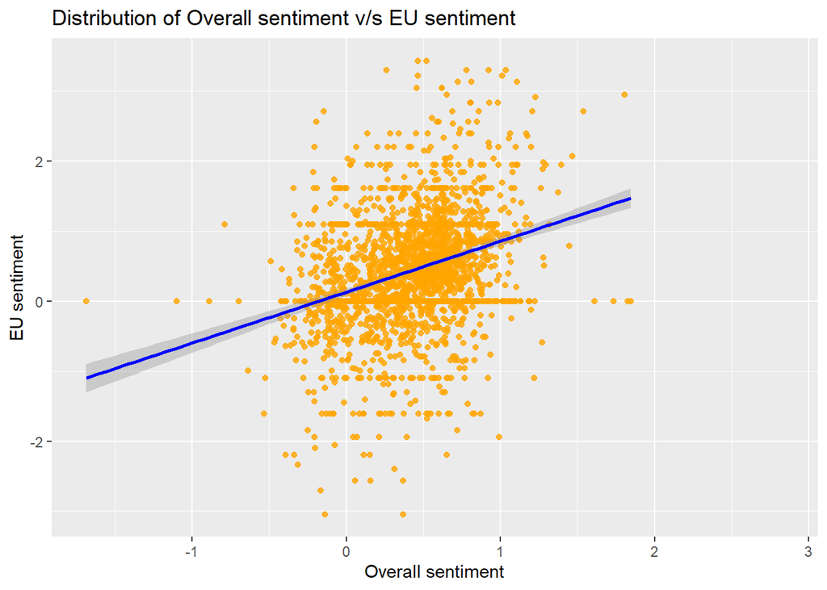

```r
dat_raw %>% ggplot(aes(x = sent.overall, y = sent.eu)) + geom_point(colour = "orange", alpha = 0.8) + geom_smooth(method = lm, colour = "blue") + labs(x = "Overall sentiment", y = "EU sentiment", title = "Distribution of Overall sentiment v/s EU sentiment")
```

```r
#check curve and smooth effect
```

10. Repeat the code from the previous question but use `facet_wrap()` to create “small multiples”/boxes for each country. [5 points]

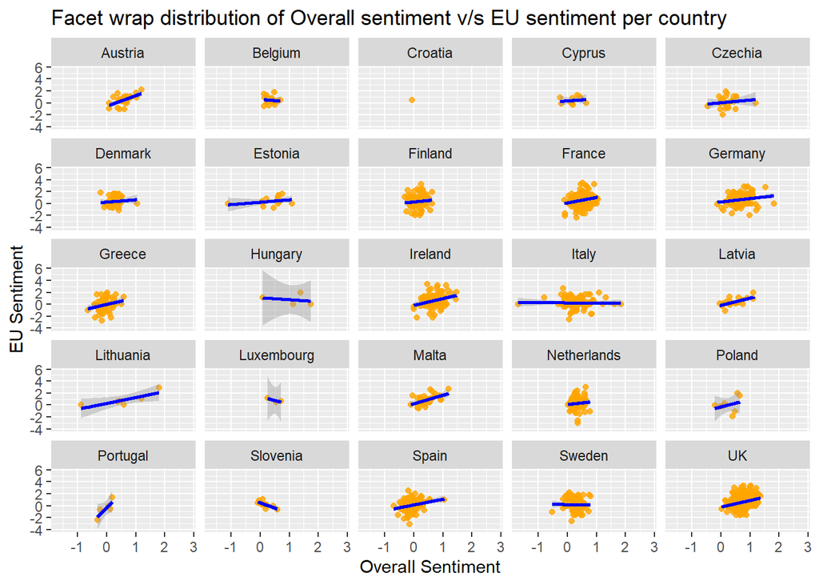

```r
options(warn=-1) #remove warnings
dat_raw %>% ggplot(aes(x = dat_raw$sent.overall, y = dat_raw$sent.eu)) + geom_point(colour = "orange", alpha = 0.8) + geom_smooth(method = lm, colour = "blue") +  facet_wrap(~dat_raw$country) + labs(x = "Overall Sentiment", y = "EU Sentiment", title = "Facet wrap distribution of Overall sentiment v/s EU sentiment per country")
```

```r
options(warn=0) #include warnings
```

11. Use the `lm()` function and reproduce Model 1 in Table 1. Use the ratio of followers after the purge in relation to before (`folrat`) as the dependent variable, and add the following independent variables: Male/Female, Terms in office, Cabinet experience, Twitter sentiment, Twitter EU sentiment, Nr. of followers (log), Seat share, In government, EU position. Note: you will need to read the codebook on Brightspace to find these variables. Store the output of this regression as `lm1`. [10 points]

*Note: your coefficients may differ slightly from the coefficients in Table 1 since Castanho Silva and Proksch apply a somewhat more complex multilevel linear regression model.*

```r
lm1 = lm(folrat ~ male + terms + min + sent.overall + sent.eu + log_fol.b + seat_share + cabinet + eu_pos , data = dat_raw)
```

12. Use `summary(lm1)` and interpret the coefficient for Twitter sentiment in substantive terms. [5 points]

```r
summary(lm1)
```

```
##
## Call:
## lm(formula = folrat ~ male + terms + min + sent.overall + sent.eu +
##     log_fol.b + seat_share + cabinet + eu_pos, data = dat_raw)
##
## Residuals:
##     Min      1Q  Median      3Q     Max
## -32.772  -0.472  -0.153   0.252  38.853
##
## Coefficients:
##               Estimate Std. Error t value Pr(>|t|)
## (Intercept)   4.353236   0.410127  10.614  < 2e-16 ***
## male         -0.103006   0.104048  -0.990   0.3223
## terms         0.040626   0.034393   1.181   0.2377
## min           0.096290   0.052927   1.819   0.0690 .
## sent.overall -0.187636   0.159772  -1.174   0.2404
## sent.eu       0.020665   0.065190   0.317   0.7513
## log_fol.b    -0.393125   0.039446  -9.966  < 2e-16 ***
## seat_share    0.011144   0.003483   3.199   0.0014 **
## cabinet       0.071052   0.122217   0.581   0.5611
## eu_pos       -0.158130   0.030740  -5.144 2.96e-07 ***
## ---
## Signif. codes:  0 '***' 0.001 '**' 0.01 '*' 0.05 '.' 0.1 ' ' 1
##
## Residual standard error: 2.198 on 1905 degrees of freedom
##   (579 observations deleted due to missingness)
## Multiple R-squared:  0.0672, Adjusted R-squared:  0.06279
## F-statistic: 15.25 on 9 and 1905 DF,  p-value: < 2.2e-16
```

*Overall Sentiment is negatively correlated with each when ratio of followers after the purge in relation to before the purge (folrat)*

13. Now reproduce Models 2, 3, and 4, and store the regressions as `lm2`, `lm3`, and `lm4`. Note: you will need to interact some of the variables (`sent.eu * radright` in Model 3 and `sent.eu * radleft` in Model 4). Are your coefficients similar to the ones in the paper? [15 points]

```r
lm2 = lm(folrat ~ male + terms + min + sent.overall + sent.eu  + log_fol.b + eu_pos +  seat_share + cabinet + radright + radleft, data = dat_raw)
summary(lm2)
```

```
##
## Call:
## lm(formula = folrat ~ male + terms + min + sent.overall + sent.eu +
##     log_fol.b + eu_pos + seat_share + cabinet + radright + radleft,
##     data = dat_raw)
##
## Residuals:
##     Min      1Q  Median      3Q     Max
## -32.715  -0.532  -0.143   0.282  38.637
##
## Coefficients:
##               Estimate Std. Error t value Pr(>|t|)
## (Intercept)   5.256602   0.442228  11.887  < 2e-16 ***
## male         -0.096776   0.103314  -0.937   0.3490
## terms         0.011603   0.034618   0.335   0.7375
## min           0.095611   0.052569   1.819   0.0691 .
## sent.overall -0.318807   0.162043  -1.967   0.0493 *
## sent.eu       0.017020   0.064800   0.263   0.7928
## log_fol.b    -0.411362   0.039378 -10.447  < 2e-16 ***
## eu_pos       -0.250419   0.035267  -7.101 1.75e-12 ***
## seat_share    0.008859   0.003497   2.533   0.0114 *
## cabinet       0.042730   0.121938   0.350   0.7261
## radright     -1.716045   0.312287  -5.495 4.43e-08 ***
## radleft      -0.315356   0.210506  -1.498   0.1343
## ---
## Signif. codes:  0 '***' 0.001 '**' 0.01 '*' 0.05 '.' 0.1 ' ' 1
##
## Residual standard error: 2.182 on 1903 degrees of freedom
##   (579 observations deleted due to missingness)
## Multiple R-squared:  0.08179,    Adjusted R-squared:  0.07648
## F-statistic: 15.41 on 11 and 1903 DF,  p-value: < 2.2e-16
```

```r
lm3 = lm(folrat ~ male + terms + min + sent.overall + sent.eu  + log_fol.b + eu_pos +  seat_share + cabinet + radright + radleft + sent.eu * radright , data = dat_raw)
summary(lm3)
```

```
##
## Call:
## lm(formula = folrat ~ male + terms + min + sent.overall + sent.eu +
##     log_fol.b + eu_pos + seat_share + cabinet + radright + radleft +
##     sent.eu * radright, data = dat_raw)
##
## Residuals:
##     Min      1Q  Median      3Q     Max
## -32.678  -0.537  -0.144   0.293  38.562
##
## Coefficients:
##                   Estimate Std. Error t value Pr(>|t|)
## (Intercept)       5.267596   0.438581  12.011  < 2e-16 ***
## male             -0.090804   0.102466  -0.886  0.37563
## terms             0.012079   0.034333   0.352  0.72500
## min               0.099190   0.052139   1.902  0.05727 .
## sent.overall     -0.297618   0.160748  -1.851  0.06426 .
## sent.eu          -0.054042   0.065451  -0.826  0.40909
## log_fol.b        -0.413241   0.039054 -10.581  < 2e-16 ***
## eu_pos           -0.249444   0.034976  -7.132 1.40e-12 ***
## seat_share        0.009056   0.003469   2.611  0.00911 **
## cabinet           0.071612   0.121036   0.592  0.55415
## radright         -1.857308   0.310689  -5.978 2.69e-09 ***
## radleft          -0.328152   0.208780  -1.572  0.11617
## sent.eu:radright  1.959440   0.342041   5.729 1.17e-08 ***
## ---
## Signif. codes:  0 '***' 0.001 '**' 0.01 '*' 0.05 '.' 0.1 ' ' 1
##
## Residual standard error: 2.164 on 1902 degrees of freedom
##   (579 observations deleted due to missingness)
## Multiple R-squared:  0.09737,    Adjusted R-squared:  0.09167
## F-statistic:  17.1 on 12 and 1902 DF,  p-value: < 2.2e-16
```

```r
lm4 = lm(folrat ~ male + terms + min + sent.overall + sent.eu  + log_fol.b + eu_pos +  seat_share + cabinet + radright + radleft + sent.eu * radleft  , data = dat_raw)
summary(lm4)
```

```
##
## Call:
## lm(formula = folrat ~ male + terms + min + sent.overall + sent.eu +
##     log_fol.b + eu_pos + seat_share + cabinet + radright + radleft +
##     sent.eu * radleft, data = dat_raw)
##
## Residuals:
##     Min      1Q  Median      3Q     Max
## -32.721  -0.532  -0.143   0.290  38.641
##
## Coefficients:
##                  Estimate Std. Error t value Pr(>|t|)
## (Intercept)      5.262886   0.442374  11.897  < 2e-16 ***
## male            -0.096900   0.103327  -0.938   0.3485
## terms            0.011310   0.034625   0.327   0.7440
## min              0.095133   0.052580   1.809   0.0706 .
## sent.overall    -0.316625   0.162094  -1.953   0.0509 .
## sent.eu          0.028799   0.066904   0.430   0.6669
## log_fol.b       -0.411609   0.039385 -10.451  < 2e-16 ***
## eu_pos          -0.251418   0.035299  -7.122 1.50e-12 ***
## seat_share       0.008724   0.003503   2.490   0.0128 *
## cabinet          0.040619   0.121990   0.333   0.7392
## radright        -1.717702   0.312336  -5.500 4.32e-08 ***
## radleft         -0.320473   0.210657  -1.521   0.1284
## sent.eu:radleft -0.180051   0.253965  -0.709   0.4784
## ---
## Signif. codes:  0 '***' 0.001 '**' 0.01 '*' 0.05 '.' 0.1 ' ' 1
##
## Residual standard error: 2.182 on 1902 degrees of freedom
##   (579 observations deleted due to missingness)
## Multiple R-squared:  0.08203,    Adjusted R-squared:  0.07624
## F-statistic: 14.16 on 12 and 1902 DF,  p-value: < 2.2e-16
```

*Co efficients are almost similar to the paper, however there could be minor differences when compared to the papers in few of the attributes due to the usage of different datasets*

14. Interpret the output for the interaction effect between Twitter EU sentiment and Radical Right Party (`sent.eu * radright`) from Model 3 in substantive terms. [5 points]

*The positive interaction effect 1.959 between Radical right and EU sentiment on Twitter from Model 3 shows that, if the estimated EU tweet sentiment increases by 1 percentage points and if the MP’s party belongs to the radical right family, there will be 1.959 percentage increase in followers.*

*The interaction effect is statistically significant since P-value (1.17e-08) is lesser than the significance level alpha = 0.05. Hence, losses in followers were concentrated among radical right parties and politicians with the most negative discourse about Europe on Twitter*

15. Use `htmlreg()` to create a regression table that contains all four models. You need to embed the models as a list in the `htmlreg()` function (see the examples in the lecture slides). Rename the coefficients using similar terms as in Table 1 of the paper. Add the following caption: Individual and Party-Level Determinants of Percentage Changes in Followers: July 9–13. [10 points]

```r
# make load the texreg package here using library(texreg) after installing this package (see instructions at the top of this script)

# note: the headline of this chunk must include `results='asis' to correctly display the regression table

library(texreg)
htmlreg(list(lm1,lm2,lm3,lm4), custom.coef.names = c("Intercept", "Male", "Terms in office", "Cabinet experience", "Twitter sentiment", "Twitter EU sentiment", "Nr. of followers (log)", "Seat share", "In government", "EU position", "Radical right", "Radical left", "Twitter EU sentiment * Radical right", "Twitter EU sentiment * Radical left"), fontsize = "footnotesize", caption = "Table 1 : Individual and Party-Level Determinants of Percentage Changes in Followers: July 9–13", caption.above = TRUE, inline.css = TRUE)
```

Table 1 : Individual and Party-Level Determinants of Percentage Changes in Followers: July 9–13

|  | Model 1 | Model 2 | Model 3 | Model 4 |
| --- | --- | --- | --- | --- |
| Intercept | 4.35*** | 5.26*** | 5.27*** | 5.26*** |
|  | (0.41) | (0.44) | (0.44) | (0.44) |
| Male | -0.10 | -0.10 | -0.09 | -0.10 |
|  | (0.10) | (0.10) | (0.10) | (0.10) |
| Terms in office | 0.04 | 0.01 | 0.01 | 0.01 |
|  | (0.03) | (0.03) | (0.03) | (0.03) |
| Cabinet experience | 0.10 | 0.10 | 0.10 | 0.10 |
|  | (0.05) | (0.05) | (0.05) | (0.05) |
| Twitter sentiment | -0.19 | -0.32* | -0.30 | -0.32 |
|  | (0.16) | (0.16) | (0.16) | (0.16) |
| Twitter EU sentiment | 0.02 | 0.02 | -0.05 | 0.03 |
|  | (0.07) | (0.06) | (0.07) | (0.07) |
| Nr. of followers (log) | -0.39*** | -0.41*** | -0.41*** | -0.41*** |
|  | (0.04) | (0.04) | (0.04) | (0.04) |
| Seat share | 0.01** | 0.01* | 0.01** | 0.01* |
|  | (0.00) | (0.00) | (0.00) | (0.00) |
| In government | 0.07 | 0.04 | 0.07 | 0.04 |
|  | (0.12) | (0.12) | (0.12) | (0.12) |
| EU position | -0.16*** | -0.25*** | -0.25*** | -0.25*** |
|  | (0.03) | (0.04) | (0.03) | (0.04) |
| Radical right |  | -1.72*** | -1.86*** | -1.72*** |
|  |  | (0.31) | (0.31) | (0.31) |
| Radical left |  | -0.32 | -0.33 | -0.32 |
|  |  | (0.21) | (0.21) | (0.21) |
| Twitter EU sentiment * Radical right |  |  | 1.96*** |  |
|  |  |  | (0.34) |  |
| Twitter EU sentiment * Radical left |  |  |  | -0.18 |
|  |  |  |  | (0.25) |
| R<sup>2</sup> | 0.07 | 0.08 | 0.10 | 0.08 |
| Adj. R<sup>2</sup> | 0.06 | 0.08 | 0.09 | 0.08 |
| Num. obs. | 1915 | 1915 | 1915 | 1915 |

p < 0.001; p < 0.01; p < 0.05

16. BONUS: Explore **ggpredict** in combination with **plot** (see https://strengejacke.github.io/ggeffects/). Reproduce Figure 2 from the paper by plotting the predicted values of the interaction effects in Models 3 and 4. You can create two plots: one for the left-hand panel of Figure 2, and one for the right-hand panel. Adjust the layout of the plot (in particular, axis labels, legends). [5 points]

```r
lm3_interaction <- ggpredict(lm3, terms = c("sent.eu", "radright"))
p_pred_lm3_interact <- plot(lm3_interaction) + labs(x = "EU Sentiment on Twitter", y = "Expected change in Followers, July 9-13", title = "Radical right") + theme(legend.position = "bottom", legend.title = element_blank()) +scale_color_manual(labels=c("Other parties","Radical Right"),values=c("red","blue"))
```

[output not shown]

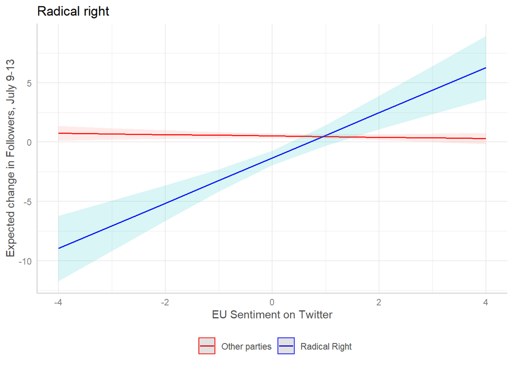

```r
p_pred_lm3_interact
```

```r
lm4_interaction <- ggpredict(lm4, terms = c("sent.eu", "radleft"))
p_pred_lm4_interact <- plot(lm4_interaction) + labs(x = "EU Sentiment on Twitter", y = "Expected change in Followers, July 9-13", title = "Radical left") + theme(legend.position = "bottom", legend.title = element_blank()) +scale_color_manual(labels=c("Other parties","Radical Left"),values=c("red","blue"))
```

[output not shown]

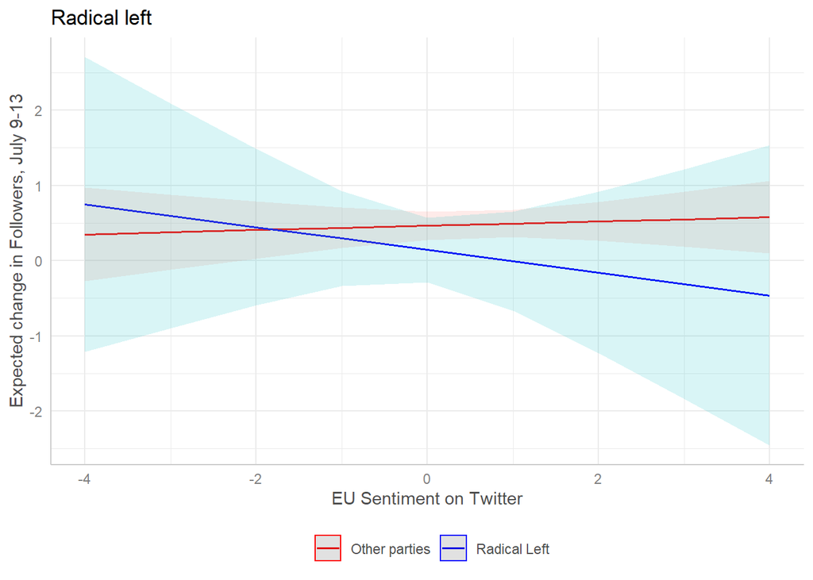

```r
p_pred_lm4_interact
```